# Week 6 Discussion

Michelle Vered

2023-02-22

# Code

Data summary

| Name | Piped data |
| --- | --- |
| Number of rows | 23 |
| Number of columns | 5 |
| _______________________ |  |
| Column type frequency: |  |
| numeric | 5 |
| ________________________ |  |
| Group variables | None |

**Variable type: numeric**

| skim_variable | n_missing | complete_rate | mean | sd | p0 | p25 | p50 | p75 | p100 | hist |
| --- | --- | --- | --- | --- | --- | --- | --- | --- | --- | --- |
| orings_at_risk | 0 | 1 | 6.00 | 0.00 | 6 | 6.0 | 6 | 6.0 | 6 | ▁▁▇▁▁ |
| num_with_thermal_distress | 0 | 1 | 0.30 | 0.56 | 0 | 0.0 | 0 | 0.5 | 2 | ▇▁▂▁▁ |
| launch_temp | 0 | 1 | 69.57 | 7.06 | 53 | 67.0 | 70 | 75.0 | 81 | ▃▁▆▇▅ |
| leak_check_pressure | 0 | 1 | 152.17 | 68.22 | 50 | 75.0 | 200 | 200.0 | 200 | ▃▁▁▁▇ |
| temporal_order_of_flight | 0 | 1 | 12.00 | 6.78 | 1 | 6.5 | 12 | 17.5 | 23 | ▇▆▇▆▇ |

# Analysis

## Links

Github Link: https://github.com/mvered/DMA3300/tree/main/week_6

Data Source Link: https://archive.ics.uci.edu/ml/datasets/Challenger+USA+Space+Shuttle+O-Ring

## Background on Data Set

This data set includes information related to the explosion of the Space Shuttle Challenger on January 28th, 1986. An investigation revealed that the explosion occurred because O-rings used in rocket construction failed on the day of launch. These O-rings were used to seal the joints on the booster rockets. The investigation found that the O-rings were vulnerable to failure when exposed to cold temperatures.

This data set contains information from 23 shuttle flights prior to the Challenger disaster. The data was collected and presented in a paper by David Draper in 1993.[^1] Although none of the previous liftoffs had the type of low temperatures observed with challenger, using a regression line, we can extrapolate how many O-rings would be predicted to be in thermal distress at lower temperatures.

## Research Question & Motivation

We are interested in understanding how launch temperature affects O-ring performance. We can measure this by comparing launch temperature with the number of O-rings experiencing thermal distress. This question is of critical importance for anyone trying to understand the Challenger disaster or plan for future safety improvements in aerospace and on future NASA projects.

## Data Description & Descriptive Statistics

The data set includes 23 observations, each representing a single Space Shuttle flight during the 1980s (prior to the Challenger explosion). There is no missing data in any of the rows.

The data set includes the following columns. Note that the original data set does not include column names, so I’ve named the columns myself based on the description of each column given by the source where I got the data from.

- **O-rings at risk:** Total number of O-rings that each Space Shuttle had, each of which could potentially fail. All shuttle flights in this data set had 6 O-rings.
- **Number with thermal distress:** The number of O-rings that displayed signs of thermal distress, indicating they could possibly fail. This ranges from 0-2.
- **Launch temperature:** Temperature at the time of launch, in Fahrenheit. This ranged from 53 to 81 degrees, with an average of 69.57 degrees.
- **Leak-check pressure:** Pressure, measured in pressure per square inch (PSI), during the leak-check test of the rockets. Pressure ranged from 50 PSI to 200 PSI, with an average of 152.17 PSI.
- **Temporal order of flight:** The order in which the flights were conducted, starting with flight #1 and going until flight #23.

## Data Analysis & Visualizations

As we can see from a scatter plot comparing launch temperature versus the number of O-rings experiencing thermal distress, it seems like lower temperatures put the O-rings at greater risk of failure. While the Space Shuttle had never been tested previously at lower launch temperatures as it was with the Challenger launch, it should have been clear to engineers that there was a concerning trend. If you extrapolate the regression line to lower temperatures, there are potentially many O-rings at risk of thermal distress and even failure.

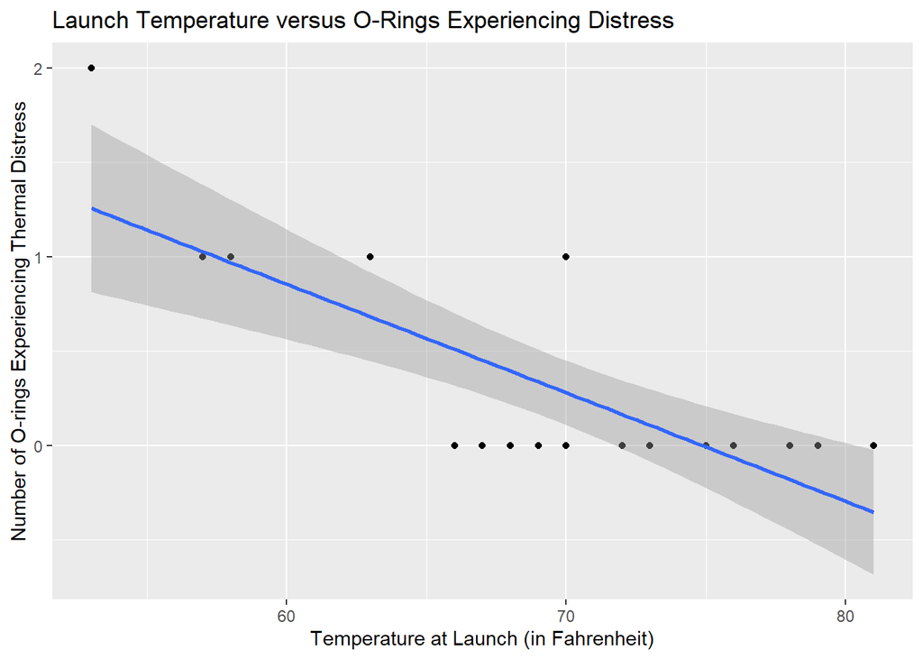

We can further dive into the relationship between distressed O-rings and launch temperature by running a simple linear regression. The number of thermally distressed O-rings would be our y-variable, our dependent variable. The temperature at launch would be our x-variable, our explanatory variable.[^2]

| term | estimate | std_error | statistic | p_value | lower_ci | upper_ci |
| --- | --- | --- | --- | --- | --- | --- |
| intercept | 4.302 | 0.831 | 5.176 | 0 | 2.573 | 6.030 |
| launch_temp | -0.057 | 0.012 | -4.833 | 0 | -0.082 | -0.033 |

The regression model output says that the y-intercept for our model is 4.302. The coefficient or slope of our launch temperature variable is -0.057. That means that for every 1 degree increase in temperature, there are 0.057 fewer O-rings at risk of thermal distress. Or to put it another way, for every 1 unit *decrease* in temperature, there are 0.057 *more* O-rings at risk of thermal distress.

The Space Shuttle Challenger was scheduled to launch with a forecasted temperature of 31 degrees Fahrenheit. Using our regression equation, we can model the number of O-rings predicted to be in thermal distress at that temperature:

$$\hat{y} = 4.302 - 0.057 * x = 4.302 -
0.057 * 31 = 2.535$$

In other words, at a launch temperature of 31 degrees, we would predict that 2.535 out of the 6 total O-rings on Challenger would experience thermal distress. That’s pretty risky!

## Findings

1. There is an inverse relationship between the number of O-rings with thermal distress and the launch temperature. The lower the launch temperature, the more O-rings that experienced thermal distress. We can see this from the scatter plot and the regression line of best fit through this data.
2. Based on our regression model, for each 1 degree decrease in launch temperature, the number of O-rings predicted to experience thermal distress increased by 0.057 units.
3. On January 28th 1986, the date of the fatal Challenger launch, the temperature was forecasted to be 31 degrees Fahrenheit. Using a linear regression, we can predict that 2.535 out of 6 O-rings would experience thermal distress at that temperature.
[^1]: Draper,D. (1993). Assessment and propagation of model uncertainty. In Proceedings of the Fourth International Workshop on Artificial Intelligence and Statistics (pp. 497--509). Ft. Lauderdale, FL: Unpublished.
[^2]: Our y-variable here (number of O-rings experiencing thermal distress) is numeric, but limited in range (the value is either 0, 1, or 2). If this were a real analysis report, we’d use another, more complicated version of regression. Our standard linear regression assumes the y-variable is continuous and approximately normally distributed. In other words, if you made a histogram of the y-variable it should look like a bell curve. But that’s not the case with our y-variable here, which is 0 for most rows, then 1 or 2 for a few rows. When we’re working with count data (that is, data that can only be positive whole numbers), we would typically use a Poisson or Negative Binomial regression model. There are also versions of Poisson and Negative Binomial regression that are adjusted to account for data where there are more zeros than any other value. These are called Zero-Inflated Poisson or Zero-Inflated Negative Binomial models. We won’t cover Poisson, Negative Binomial, or Zero-Inflated models in this class, but you should know that those models exist. The difference between a standard linear regression and the Poisson or Negative Binomial regressions is that the math we use to write out the equation of our regression line is a little bit different. With Poisson, the equation for our regression line would be: log(y) = b_0 + b_1 X. So we’re essentially just taking the log of y and using that in our regression instead of y.